# CSD Automatic Production Estimate from Dredge System Data

William Sayer

7/27/2020

# 1 Introduction

The purpose of this document is to:

- give insight into the capabilities of [Python](https://www.python.org/) and [R](https://www.r-project.org/about.html) and how they are used for data modeling
- present what [RMarkdown](https://rmarkdown.rstudio.com/lesson-1.html) has to offer in terms of creating **reproducible reports**
- prototype two models to estimate CSD production for the Alaska and Illinois based strictly on Dredge System data
- give basic insight into how models are analyzed during development in order to optimize and test their integrity
- establish a **data pipeline** such that this modeling procedure and report can be seamlessly repeated with new dredge data, new data features (i.e. blow count, cutter type, D50), different dredges, or a different model formula

## 1.1 R & Python

R & Python are both *prototyping languages* that allow for faster testing and development of data models than traditional programming languages such as C++ and Java, which makes them the most popular tools of choice for data modeling. They are both free and open source and have libraries devoted specifically to machine learning such as [Keras](https://keras.io/), [scikit-learn](https://scikit-learn.org/stable/), [CARET](http://topepo.github.io/caret/index.html), and more.

# 2 Methods

## 2.1 Python Processing

The data provided in `CSDFinal.csv` was used to fit the model in this example. This data includes all Alaska and Illinois data from 2012-present. Both `Daily` and `Plant` data were downloaded from Dredge System.

The data in `CSDFinal.csv` is the output of a Python script which joins the `Daily` and `Plant` data files and performs the following:

- determines if a booster was operational by having > 5 RevHrs
- classifies the number of “operational” boosters per day (Jesse and Buster = 2 bstrs, all others = 1)
- joins the two datasets into the final `CSDFinal.csv`, hence the `NumBstr` column all the way to the right in the file

## 2.2 Daily Filter Cleaning

Once `CSDFinal.csv` is built, it gets loaded into this RMarkdown script (the file you’re reading is the `.html` output of the RMarkdown script) with only the following fields listed below:

```r
req_fields = c("ProjectNumber", "PrimePhaseNumber", "DigQty", "WorkHrs", "Area", "Travel",
               "Rock",  "BlastedRock", "WeatheredRock", "Gravel",   "Shell",    "MudSilt",
               "FineSand", "MediumSand",    "CoarseSand",   "SoftClay", "MediumClay",   "StiffClay",
               "FloatHoseLength",   "SinkHoseLength", "PontoonPipeLength", "SublineLength",
               "UnscopedShorePipeLength", "ShorePipeLength",
               "BottomOfSuction", "NumBstr")
```

The data is then cleaned to remove all days that fail in any of the following filters:

- WorkHrs > 8 hrs
- Coverage < 40000 sqft
- DailyVolume < 10^{5} CY
- Production < 4300 CY/WH
- BottomOfSuction > 10 ft
- DigFace > 1 ft and DigFace < 10 ft
- TotalPipeLine > 3000 ft and TotalPipeLine < 10^{5} ft
- CutWidth < 600 ft

Before applying these filters we had **2308 days** of data between the two dredges. After applying the filters we are now left with **1566 days**.

## 2.3 Material Distribution

Next I look at material type distribution to determine if it is appropriate to include all material types. The barplot below shows the number of days where a material type is recorded as > 0%

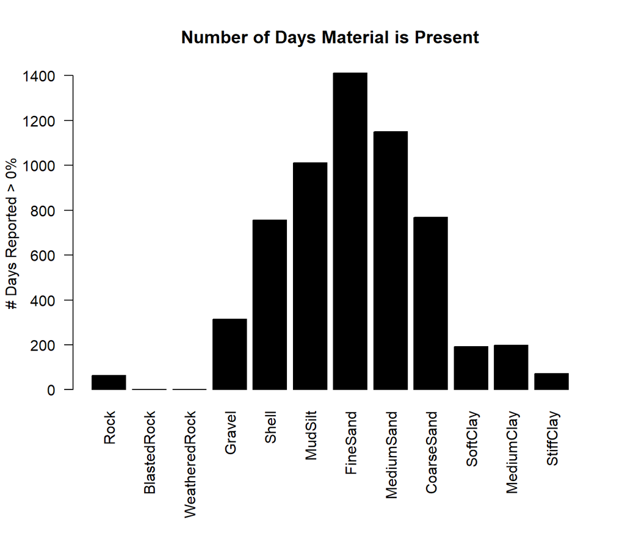

Judging from the barplot and knowing that the Alaska and Illinois are typically not utilized for rock or stiff clay, I will remove these fields from the dataset to prevent overfitting.

```r
clean_df = subset(clean_df, select = -c(Rock, BlastedRock, WeatheredRock, StiffClay))
```

## 2.4 Test/Train Split

Next I randomly split the cleaned dataset into a training set (60%) and a test set (40%).

```r
# shuffle dataset
set.seed(19930413)

train_split = 0.6
train_size = round(nrow(clean_df) * train_split, 0)

train_idx = sample(1:nrow(clean_df), train_size)
test_idx = setdiff(seq(1, nrow(clean_df)), train_idx)

train_set = clean_df[train_idx, ]
test_set = clean_df[test_idx, ]
```

The training set has 940 dredge days and the test set has 626 days. The training set will be used to fit the model, and the test set will be used to test performance and overfitting.

# 3 Simple Model

## 3.1 Description

The first model I’ll try will be the simplest model that includes all predictors. I fit a **multiple linear regression** to the following equation:

$$Coverage = \beta_0 + \beta_1*Face + \beta_2*Gravel + ... + \beta_9*MedClay + \beta_{10}*NumBstr +$$

$$\beta_{11}*BottomOfSuction + \beta_{12}*CutWidth + \beta_{13}*TotalPipeline$$

Where the $\beta$ parameters are fit by minimizing residual error. Once the parameters are fit, this formula can be used to estimate coverage/production using R, Python, Excel, or even hand calculated on paper (but would not recommend it!).

## 3.2 Diagnostics

### 3.2.1 Residuals vs Fitted

This plot tests for the **linearity** and **equal variance** assumptions that are inherently made in a linear regression. A good fit shows:

- equally distributed residuals across all fitted values
- a mean of 0 across all fitted values

Essentially, we want the spread to be even, horizontal, and centered around zero. The horn shape in the graph below displays unequal, non-linear residuals. The linearity and equal variance assumptions are definitely suspect here.

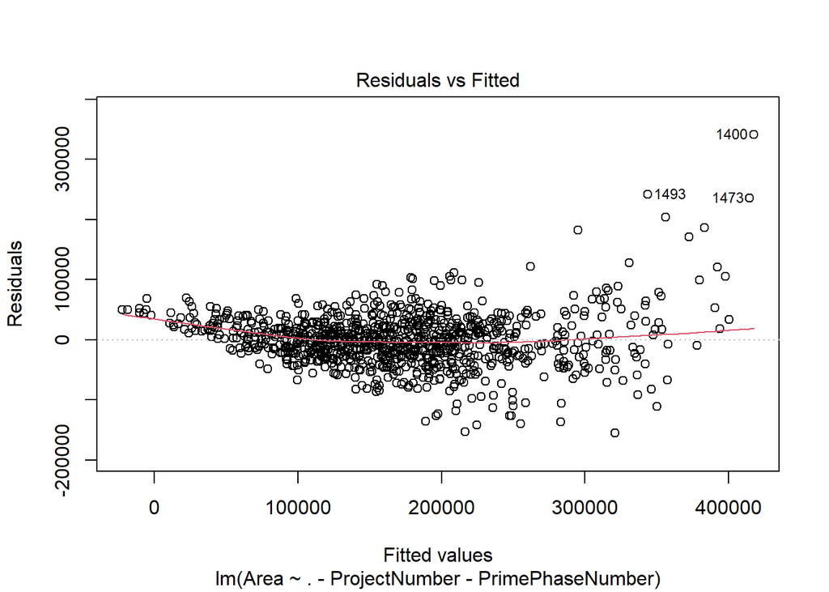

### 3.2.2 Normal Q-Q

This plot tests for the **normality** assumption that is inherently made in a linear regression (error is normally distributed about the regression). A good fit should be linear following the dotted line. Here the center doesn’t look bad, but it seems normality is lost on the tails as they vear off, so we may want to try for a better option.

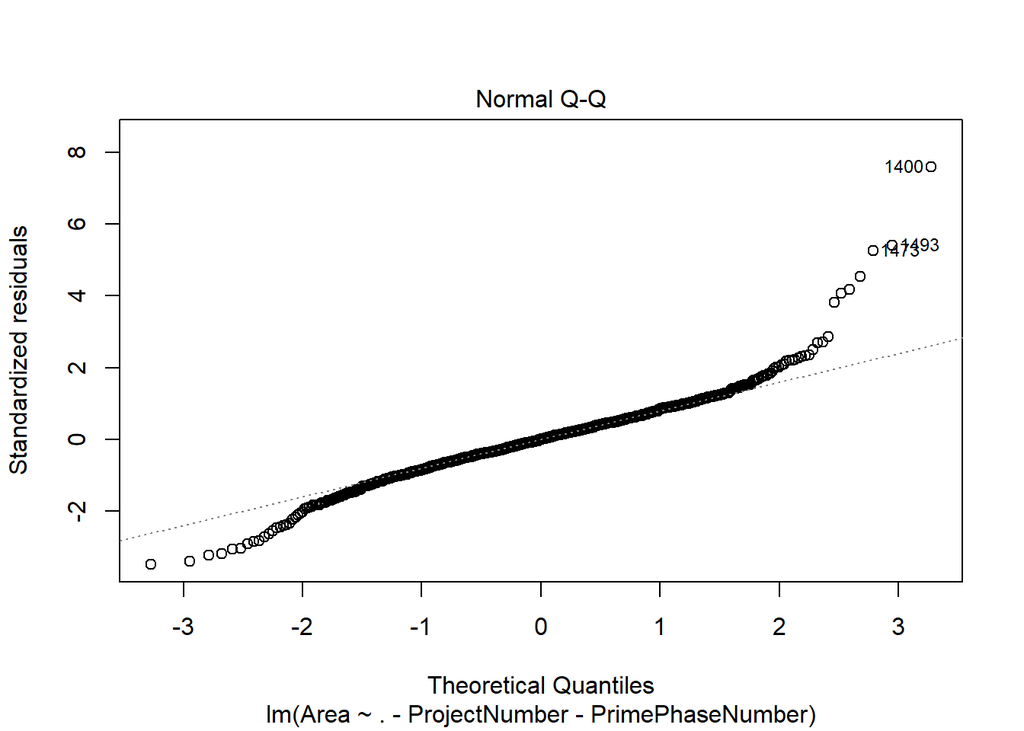

### 3.2.3 Cook’s Distance

Cook’s Distance is a quick way to check for outliers. The heuristic used to determine outliers is dependent on sample size. For this sample, any data point with a Cook’s Distance > 0.0064 is suspect of being an outlier, so 32 of our 940 observations are suspect of being outliers.

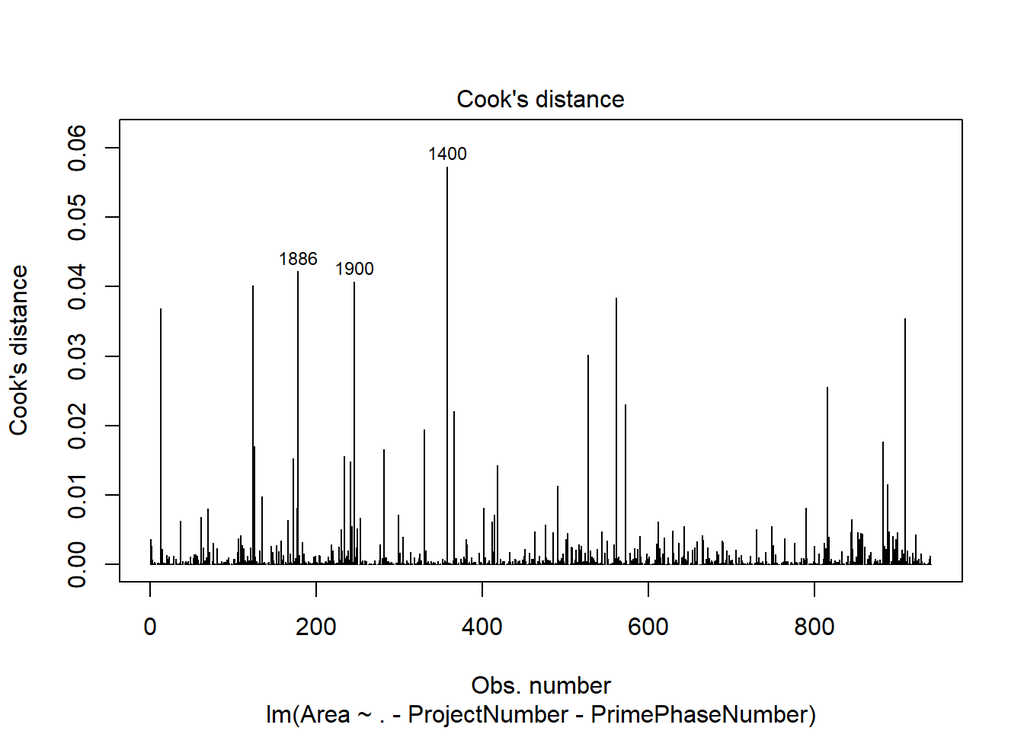

# 4 Log Model

## 4.1 Description

After series of trials using the graphs detailed above along with some other statistical testing tools, I fit a more complicated **multiple linear regression** that utilizes a log transformation on the response as well as some other transformations and interactions. This model upholds the assumptions made in a linear regression a little bit better. The formula for the log model is:

$$ln(Coverage) = \beta_0 + \beta_1*CutWidth + \beta_2*ln(CutWidth) +$$

$$\beta_3*Gravel + ... + \beta_{10}*MedClay +$$

$$\beta_{11}*NumBstr*ln(TotalPipeline) +$$

$$\beta_{12}*BottomOfSuction + \beta_{13}*Face*ln(BottomOfSuction^2) +$$

$$\beta_{14}*Face + \beta_{15}*Face^{2}$$

Where the $\beta$ parameters are fit by minimizing residual error.

## 4.2 Diagnostics

### 4.2.1 Residuals vs Fitted

The results aren’t perfect, but the **linearity** and **equal variance** assumptions have significantly improved.

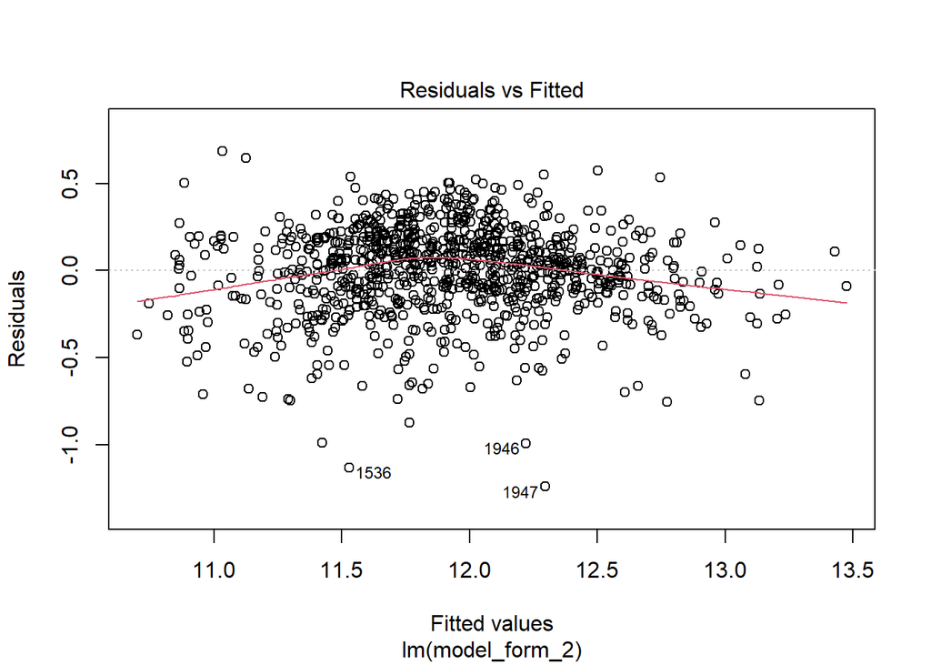

### 4.2.2 Normal Q-Q

The upper tail on this plot has significantly improved, making the **normality** assumption less suspect. The lower tail is still off, but overall this is great improvement.

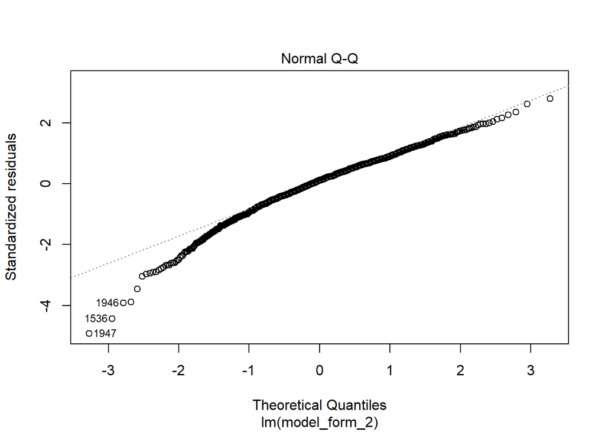

### 4.2.3 Cook’s Distance

For this sample, any data point with a Cook’s Distance > 0.0064 is suspect of being an outlier, so 36 of our 940 observations are suspect of being outliers.

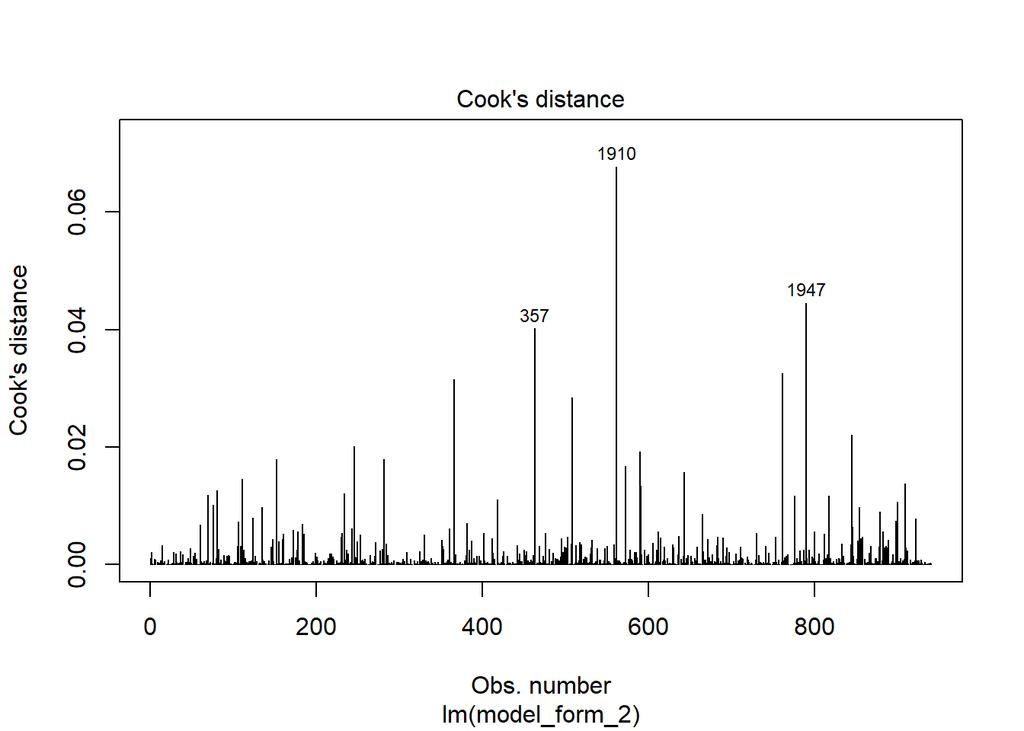

# 5 RMSE Comparison

A common way to test the performance of a model, compare it to others, and test for overfitting is by calculating the **root mean square error (RMSE)** for both the train and test sets. A test RMSE that is significantly larger than the train RMSE suggests the model was overfit to the training set.

The table below displays the test and train RMSE values for the daily entries (60/40 split), and then I have also calculated an RMSE on the **subjob averages** since there is less fluctuation in the averages, and they are our target during estimating.

However it is important to note the **SJ averages were calculated on the full dataset** so they indirectly contain train data. In the future I will select test and train data based on random selection of subjobs in order to fully separate the test and train data for SJ average anaysis.

Due to the way the model was fit, the **RMSE values are calculated in terms of Area (sqft)**.

|  | Train RMSE Daily (sqft) | Test RMSE Daily (sqft) | SJ Avg RMSE (sqft) |
| --- | --- | --- | --- |
| Simple Model | 44798 | 47977 | 37672 |
| Log Model | 43346 | 47897 | 39248 |

Looking at the daily test RMSE, it seems the **Log Model** is slightly better, but the two are relatively equivalent.

# 6 Simple Model Performance

## 6.1 Daily Basis

### 6.1.1 Production vs Face

Not bad, but some of the higher production is missed on the lower face and some of the fitted values above 7 ft are very low with a few negative production estimates.

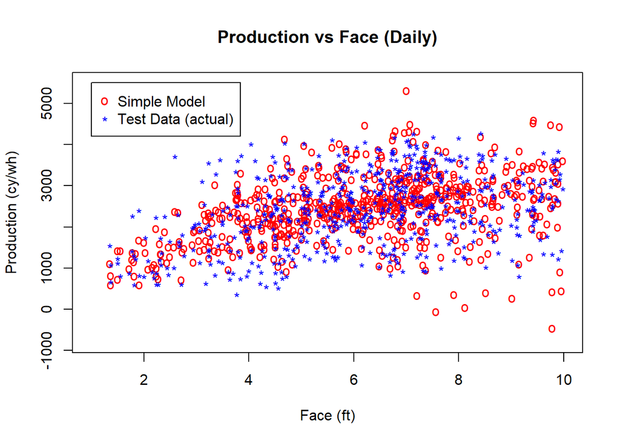

### 6.1.2 Coverage vs Face

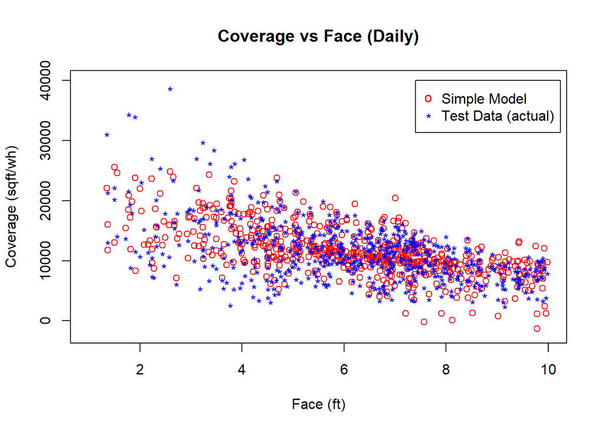

### 6.1.3 Production Residual % vs Face

This plot displays the residual of the production estimate as a percentage of the fitted value. Think of it as our production performance compared to the estimate.

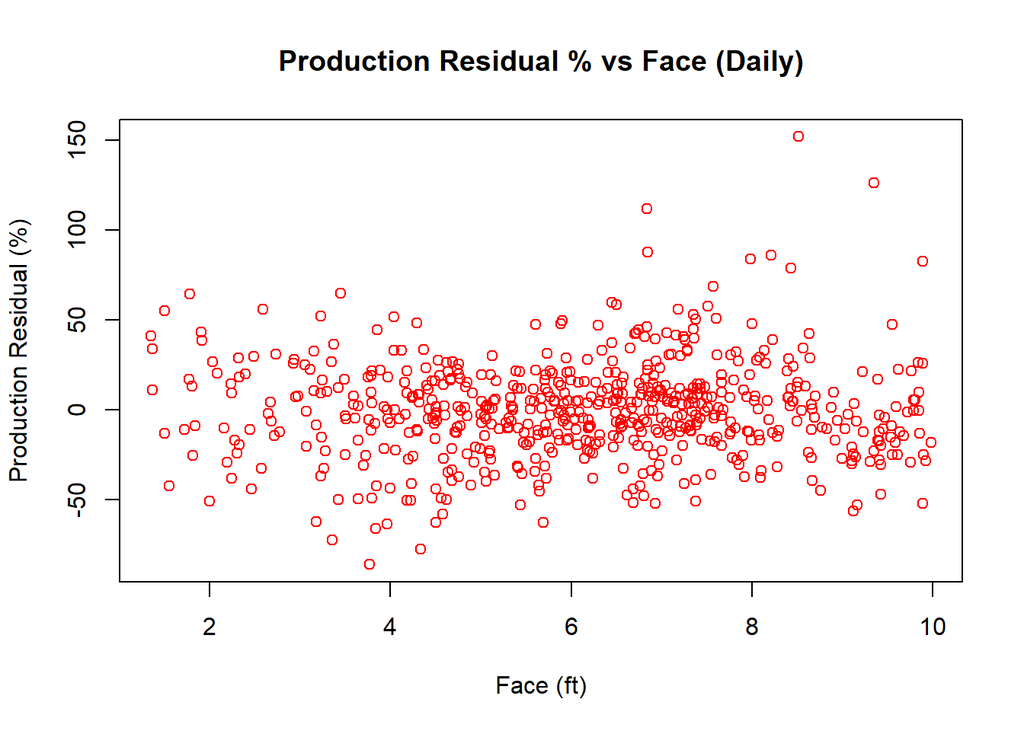

### 6.1.4 Histogram of Production Residual %

A histogram of the same data from Figure 6.1.3.

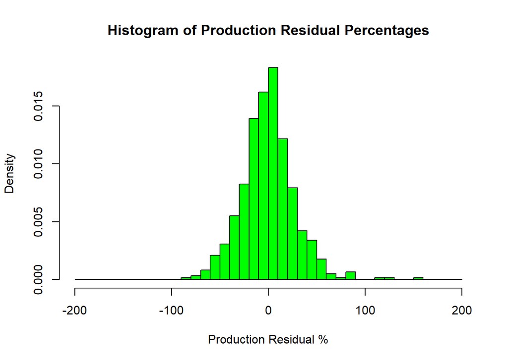

### 6.1.5 Quantiles

These quantiles represent the same data from Figures 6.1.3 and 6.1.4. These numerically describe the error distribution. Effectively what this says is:

- 50% of the time the actual production is within **15.4427%** of the model estimation
- 80% of the time the actual production is within **33.3106%** of the model estimation

The even distribution on this model and centered median indicate this is an unbiased estimator of production.

|  | 10% | 25% | 50% | 75% | 90% |
| --- | --- | --- | --- | --- | --- |
| Production Residual % | -33.72 | -15.73 | 0.0026 | 15.15 | 32.9 |

## 6.2 Subjob Average Basis

### 6.2.1 Production vs Face

The results on sub job averages show significantly better results.

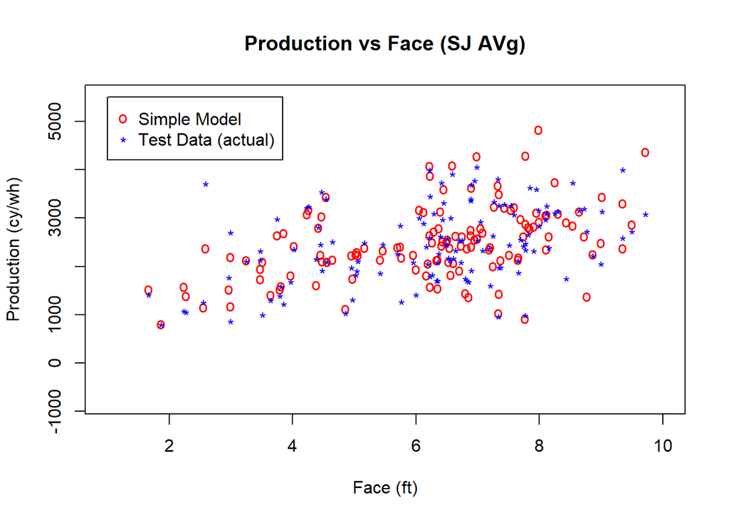

### 6.2.2 Coverage vs Face

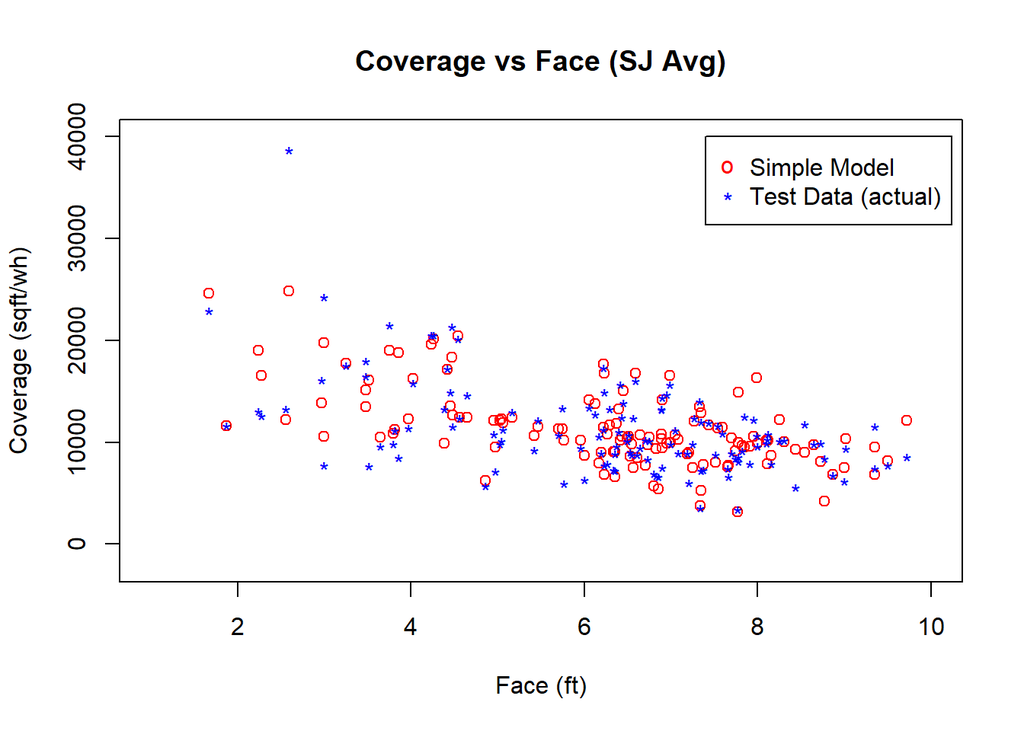

### 6.2.3 Production Residual % vs Face

This plot displays the residual of the production estimate as a percentage of the fitted value. Think of it as our production performance compared to the estimate.

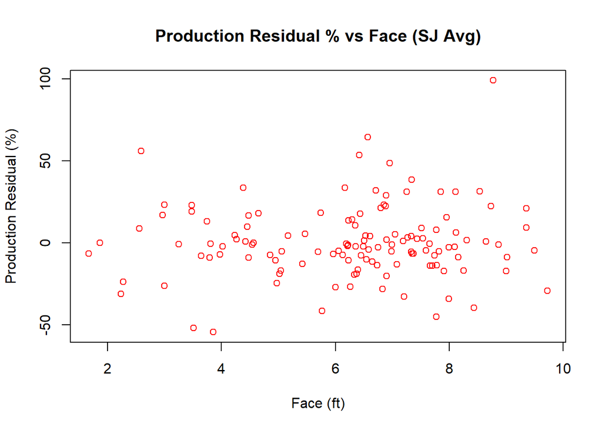

### 6.2.4 Histogram of Production Residual %

A histogram of the same data from Figure 6.2.3.

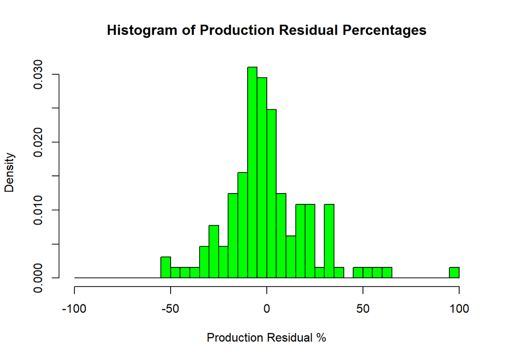

### 6.2.5 Quantiles

These quantiles represent the same data from Figures 6.2.3 and 6.2.4. These numerically describe the error distribution. Effectively what this says is:

- 50% of the time the actual production is within **10.2819%** of the model estimation
- 80% of the time the actual production is within **27.1413%** of the model estimation

The even distribution on this model and centered median indicate this is an unbiased estimator of production.

|  | 10% | 25% | 50% | 75% | 90% |
| --- | --- | --- | --- | --- | --- |
| Production Residual % | -24.95 | -10.83 | -1.362 | 9.738 | 29.33 |

# 7 Log Model Performance

## 7.1 Daily Basis

### 7.1.1 Production vs Face

Looking at this chart compared to the Simple Model it seems the Log Model performs much better on the boundary conditions of face.

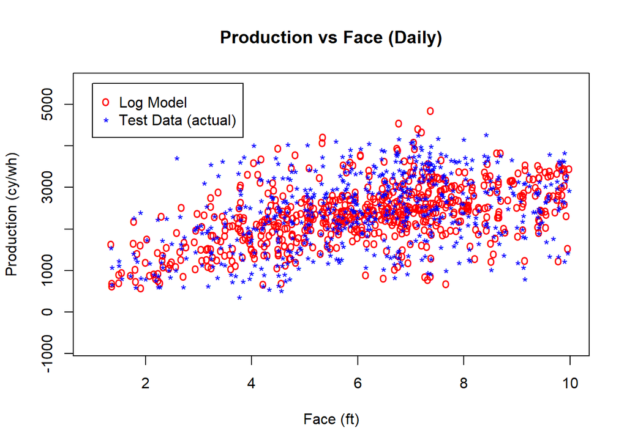

### 7.1.2 Coverage vs Face

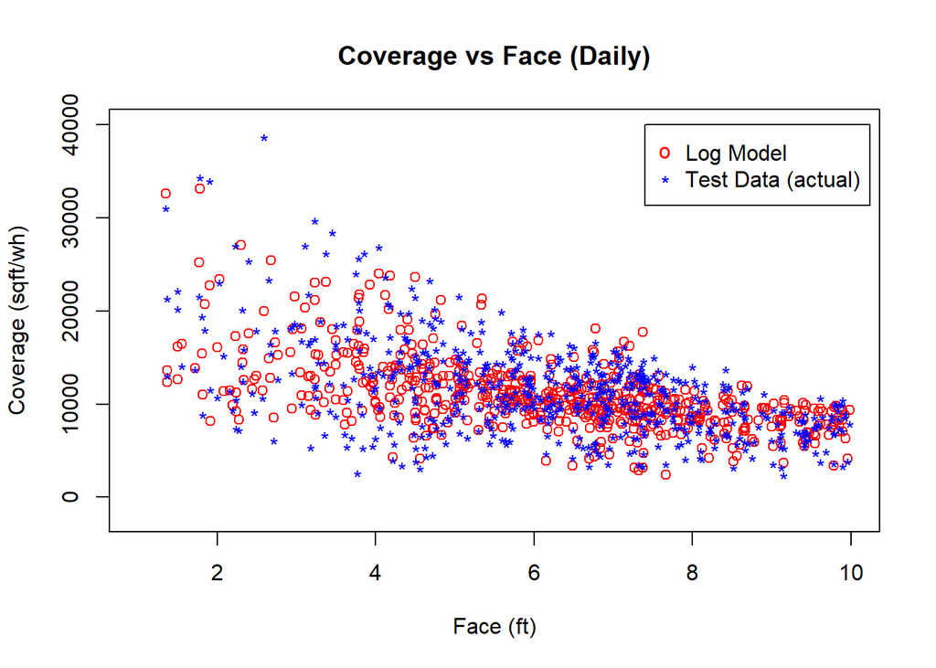

### 7.1.3 Production Residual % vs Face

This plot displays the residual of the production estimate as a percentage of the fitted value. Think of it as our production performance compared to the estimate.

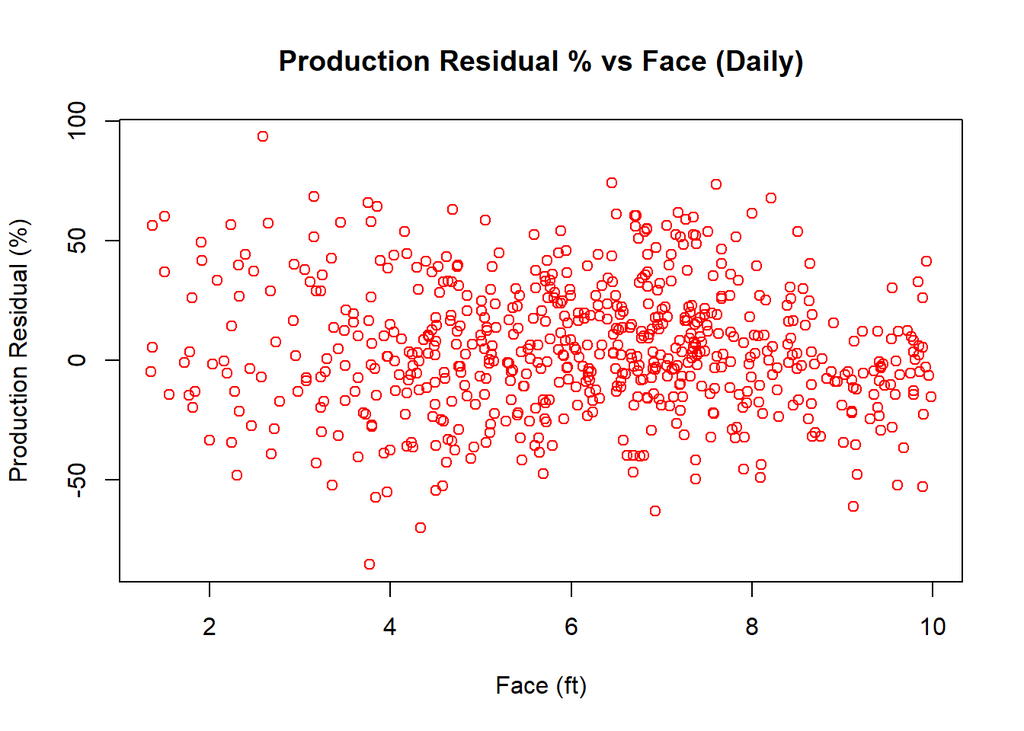

### 7.1.4 Histogram of Production Residual %

A histogram of the same data from Figure 7.1.3.

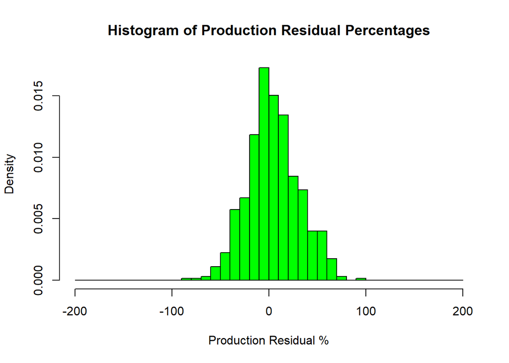

### 7.1.5 Quantiles

These quantiles represent the same data from Figures 7.1.3 and 7.1.4. These numerically describe the error distribution. Effectively what this says is:

- 50% of the time, the estimated production is within the bounds of being **12.5926% aggressive** and **21.2051% conservative**
- 80% of the time, the estimated production is within the bounds of being **29.3643% aggressive** and **40.3025% conservative**
- the median performance of the model is **2.6911%** conservative

The skew on this model and non-zero median indicate this is a biased estimator on the conservative side.

|  | 10% | 25% | 50% | 75% | 90% |
| --- | --- | --- | --- | --- | --- |
| Production Residual % | -29.36 | -12.59 | 2.691 | 21.21 | 40.3 |

## 7.2 Subjob Average Basis

### 7.2.1 Production vs Face

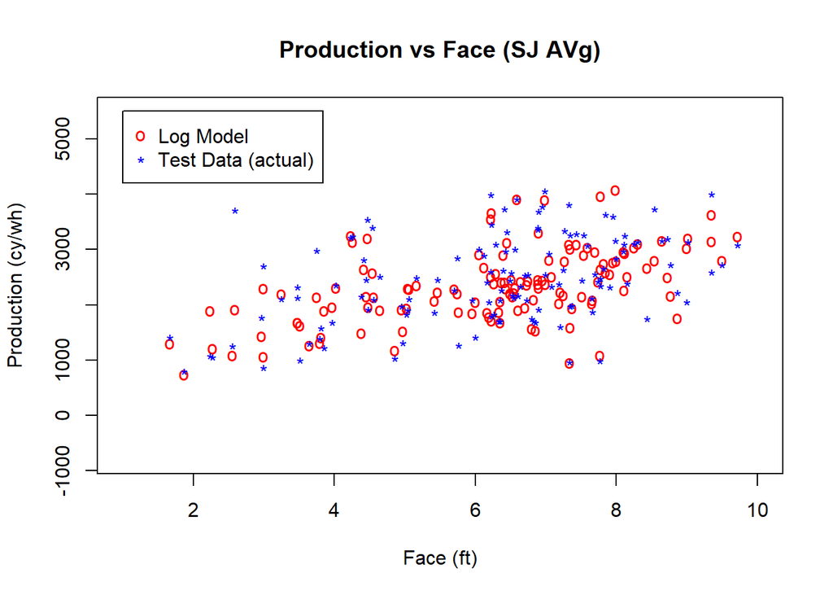

### 7.2.2 Coverage vs Face

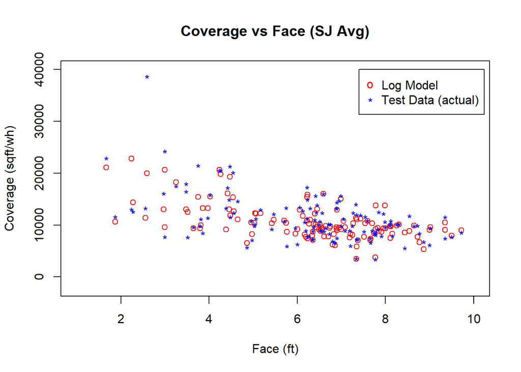

### 7.2.3 Production Residual % vs Face

This plot displays the residual of the production estimate as a percentage of the fitted value. Think of it as our production performance compared to the estimate.

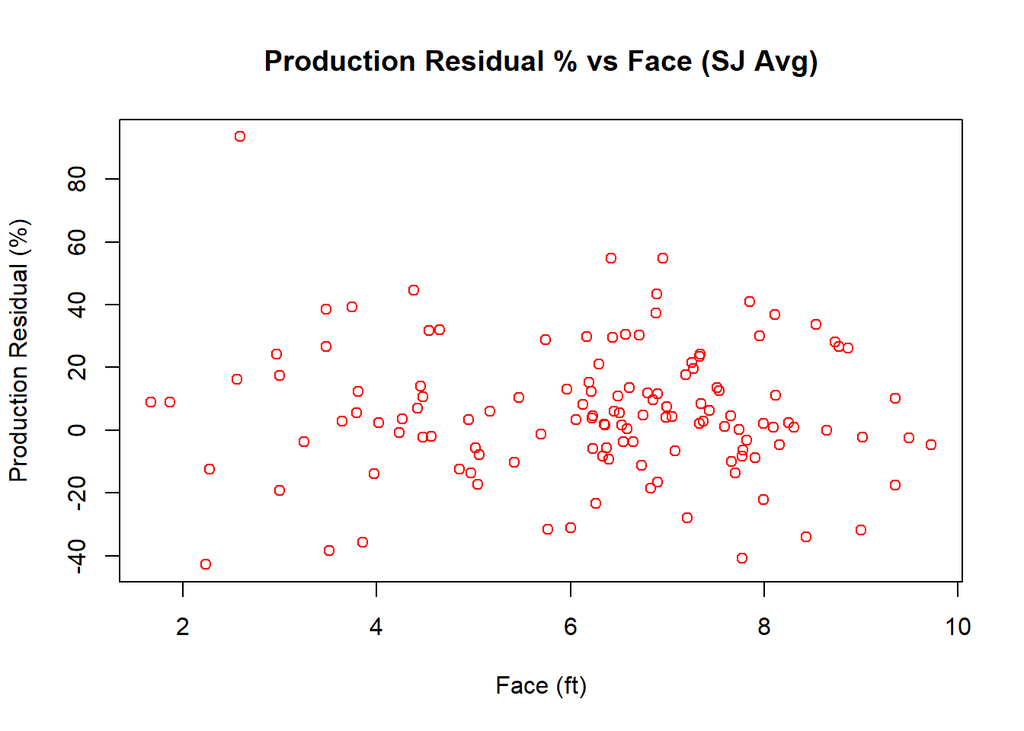

### 7.2.4 Production Residual % vs Gravel

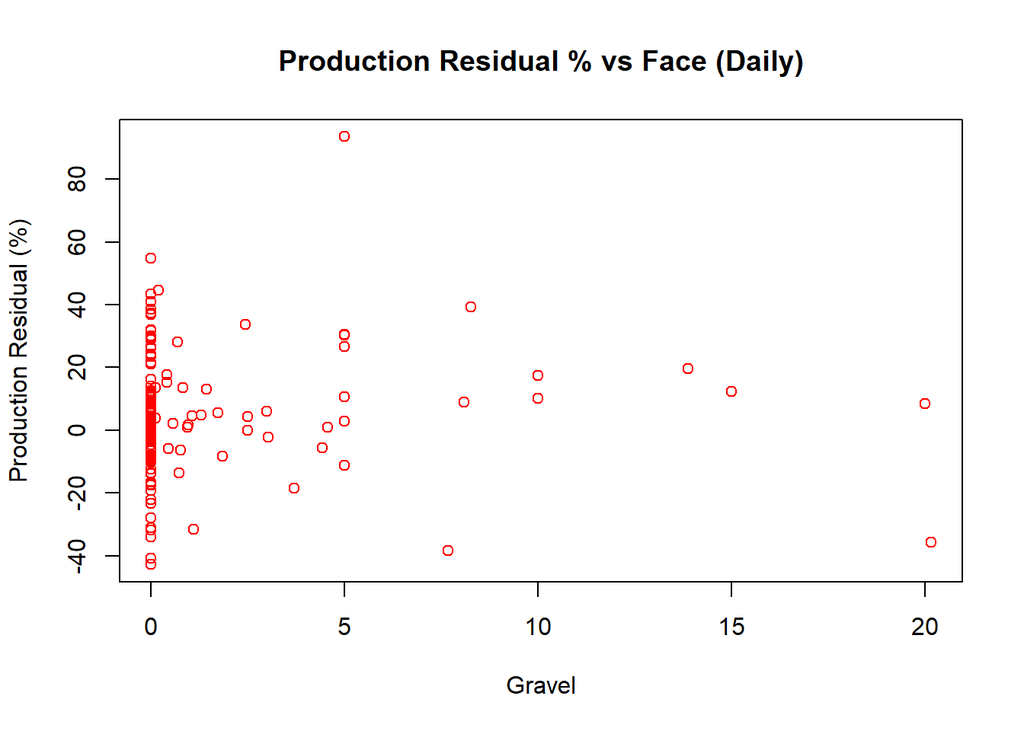

### 7.2.5 Production Residual % vs Shell

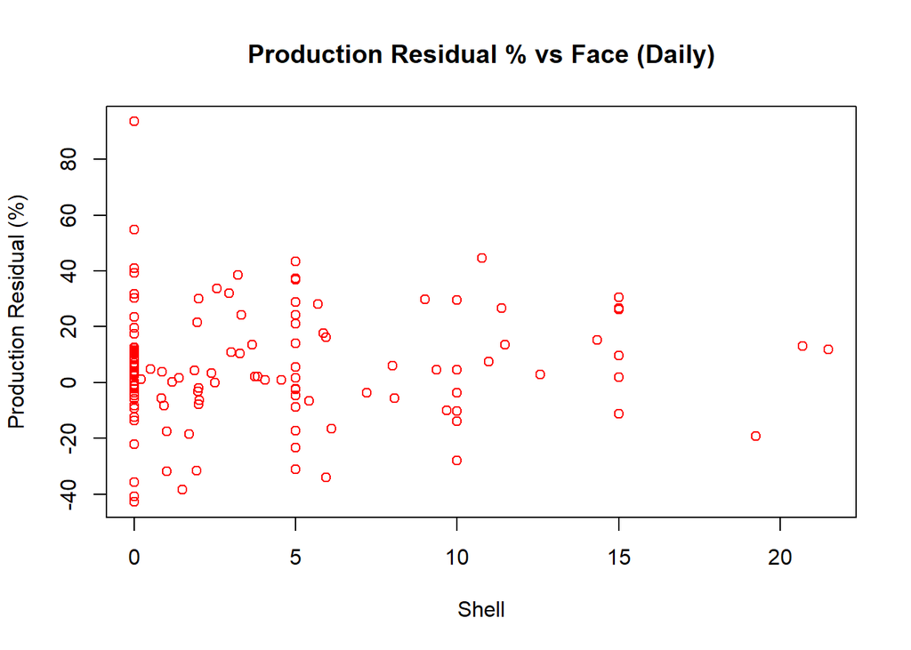

### 7.2.6 Production Residual % vs Mud/Silt

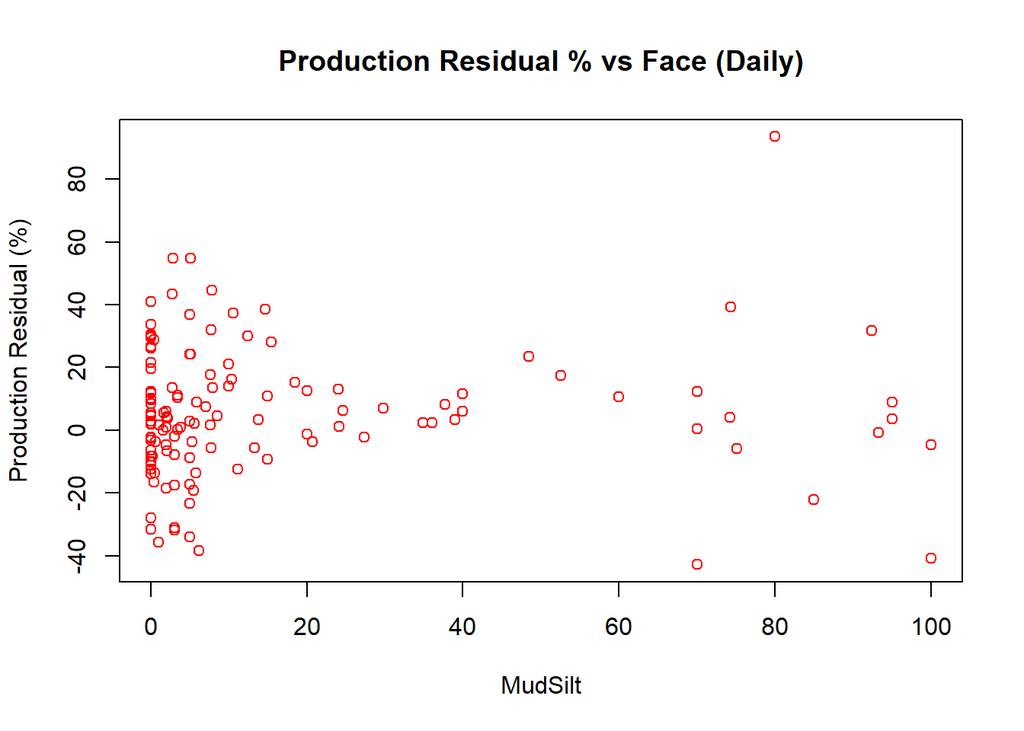

### 7.2.7 Production Residual % vs Fine Sand

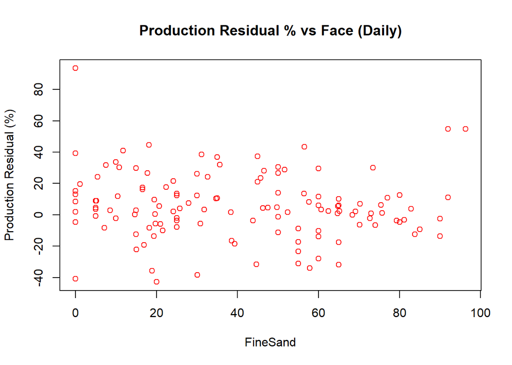

### 7.2.8 Production Residual % vs Medium Sand

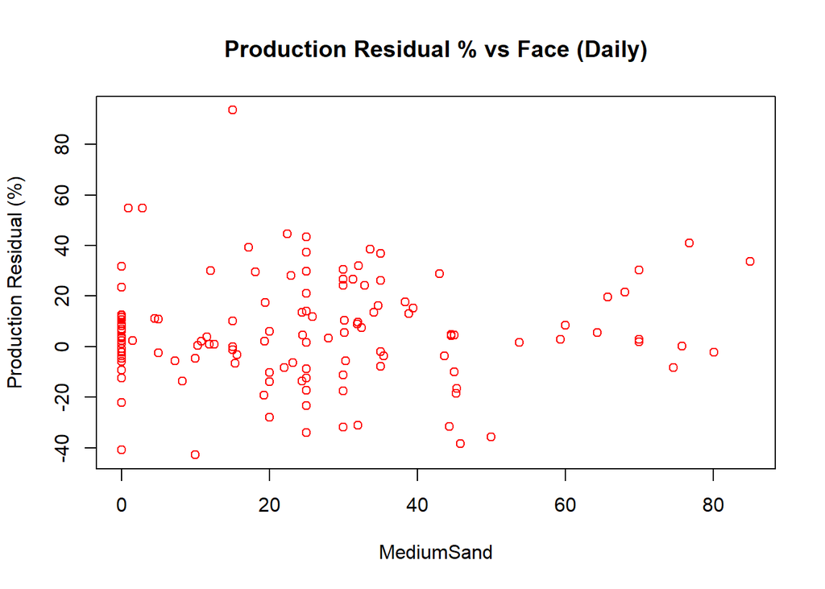

### 7.2.9 Production Residual % vs Coarse Sand

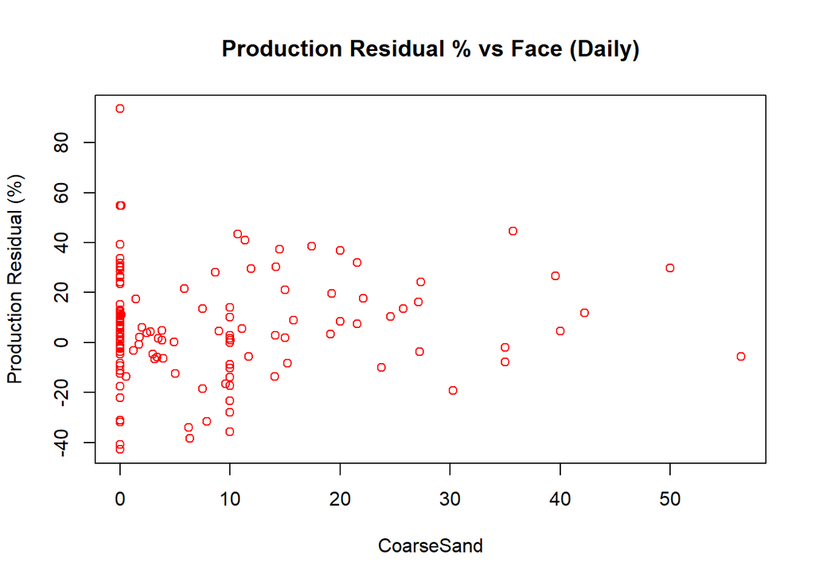

### 7.2.10 Histogram of Production Residual %

A histogram of the same data from Figure 7.2.3.

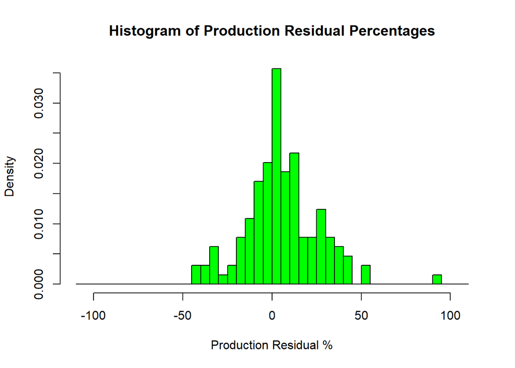

### 7.2.11 Quantiles

- 50% of the time, the estimated production is within the bounds of being **5.7249% aggressive** and **15.3807% conservative**
- 80% of the time, the estimated production is within the bounds of being **17.7386% aggressive** and **30.767% conservative**
- the median performance of the model is **3.8364%** conservative

The skew on this model and non-zero median indicate this is a biased estimator on the conservative side.

|  | 10% | 25% | 50% | 75% | 90% |
| --- | --- | --- | --- | --- | --- |
| Production Residual % | -17.74 | -5.725 | 3.836 | 15.38 | 30.77 |

# 8 Conclusion

To summarize the findings from what has been presented:

Overall I’d say the **Log Model** is the better choice between the two. It seems to be more robust, and from an estimating perspective, lower risk as it tends to estimate on the conservative end (**50% of the time**, the estimated production is within the bounds of being **5.7249% aggressive** and **15.3807% conservative** for SJ avg).

The purpose of this exercise was give a quick presentation on what we can get in terms of producing an automated production estimate strictly from Dredge System data. It is possible there is a better formula to use on this data, but including new data features and/or project relationships can also make a significant difference.

Another purpose of this excercise was to establish a data pipeline for this procedure (and this report) such that it can be streamlined quite seamlessly; however even once established, the pipeline still needs its own sort of maintenance and can always be further improved to operate more efficiently.